# **Projekt "Kaufen oder Warten"?**

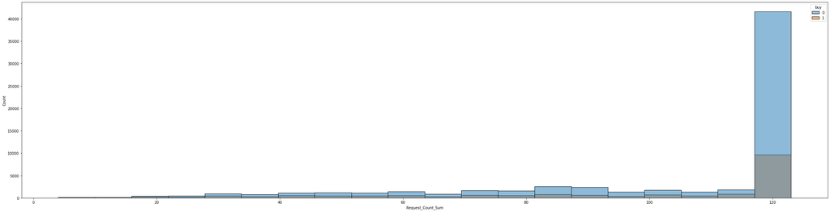

```python
plt.figure(figsize=(40,10))
sns.histplot(x="Request_Count_Sum", hue="buy", data=train_set_v2, bins=20)
plt.show()
```

Hier ist jedoch zu erkennen, dass die Preisentwicklung einen Einfluss auf den Anteil der Kaufempfehlungen hat. Der Anteil an Kaufempfehlungen nimmt zu, wenn der Preis fällt.

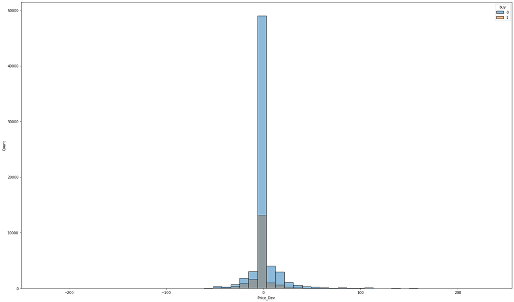

```python
plt.figure(figsize=(25,15))
sns.histplot(x="Price_Dev", hue="buy", data=train_set_v2, bins=50)
plt.show()
```

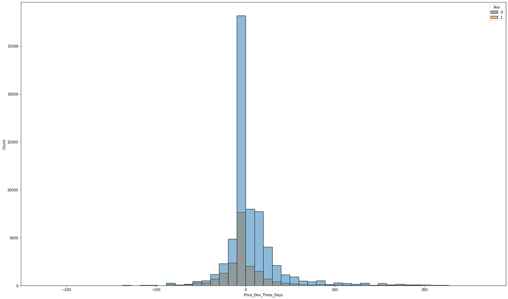

```python
plt.figure(figsize=(25,15))
sns.histplot(x="Price_Dev_Three_Days", hue="buy", data=train_set_v2, bins=50)
plt.show()
```

Bevor die Vorverarbeitung beendet ist, müssen die verbliebenen qualitative Daten in Zahlen codiert werden. Dafür werden die encoder ordinal encoder und one hot encoding verwendet. Wobei der one hot encoder für Features, die keine natürliche Ordnung haben, verwendet wird.

```python
train_set_v2.info()
```

```
<class 'pandas.core.frame.DataFrame'>
RangeIndex: 83624 entries, 0 to 83623
Data columns (total 26 columns):
 #   Column                               Non-Null Count  Dtype
---  ------                               --------------  -----
 0   buy                                  83624 non-null  int64
 1   Price_In_Eur                         83624 non-null  float64
 2   Price_Dev                            83624 non-null  float64
 3   Price_Dev_Three_Days                 83624 non-null  float64
 4   Request_Day                          83624 non-null  object
 5   Request_Month                        83624 non-null  int64
 6   Request_Time                         83624 non-null  int64
 7   Last_Request_Bool                    83624 non-null  int64
 8   Flight_Day                           83624 non-null  object
 9   Departure_hour                       83624 non-null  int64
```

[output cut: 18 more lines]

```python
train_set_v2.describe()
```

|  | buy | Price_In_Eur | Price_Dev | Price_Dev_Three_Days | Request_Month | Request_Time | Last_Request_Bool | Departure_hour | Hours_to_Flight | Request_Count | Request_Count_Sum | Is_Holiday_UK | Is_Holiday_GER | Is_School_Holiday_BER | Is_School_Holiday_FRA | Is_School_Holiday_UK | Same_Day_Route_Flight_avg_price | Same_Day_Route_Flight_avg_price_utd | Same_Day_Request_route_Flight_price |
| --- | --- | --- | --- | --- | --- | --- | --- | --- | --- | --- | --- | --- | --- | --- | --- | --- | --- | --- | --- |
| count | 83624.00 | 83624.00 | 83624.00 | 83624.00 | 83624.00 | 83624.00 | 83624.00 | 83624.00 | 83624.00 | 83624.00 | 83624.00 | 83624.00 | 83624.00 | 83624.00 | 83624.00 | 83624.00 | 83624.00 | 83624.00 | 83624.00 |
| mean | 0.22 | 71.97 | 0.97 | 5.41 | 6.46 | 16.98 | 0.01 | 12.97 | 929.92 | 48.44 | 103.34 | 0.04 | 0.00 | 0.36 | 0.41 | 0.78 | 6.86 | 6.86 | 6.64 |
| std | 0.42 | 54.79 | 16.09 | 30.98 | 0.55 | 6.00 | 0.11 | 6.18 | 548.57 | 35.56 | 29.25 | 0.21 | 0.04 | 0.48 | 0.49 | 0.42 | 25.09 | 25.09 | 26.94 |
| min | 0.00 | 8.99 | -226.44 | -226.44 | 6.00 | 11.00 | 0.00 | 6.00 | 19.00 | 1.00 | 4.00 | 0.00 | 0.00 | 0.00 | 0.00 | 0.00 | 0.00 | 0.00 | 0.00 |
| 25% | 0.00 | 32.77 | 0.00 | -3.30 | 6.00 | 11.00 | 0.00 | 7.00 | 475.00 | 17.00 | 89.00 | 0.00 | 0.00 | 0.00 | 0.00 | 1.00 | 0.00 | 0.00 | 0.00 |
| 50% | 0.00 | 55.08 | 0.00 | 0.00 | 6.00 | 11.00 | 0.00 | 10.00 | 883.00 | 44.00 | 121.00 | 0.00 | 0.00 | 0.00 | 0.00 | 1.00 | 0.00 | 0.00 | 0.00 |
| 75% | 0.00 | 91.79 | 0.00 | 11.44 | 7.00 | 23.00 | 0.00 | 19.00 | 1328.00 | 77.00 | 122.00 | 0.00 | 0.00 | 1.00 | 1.00 | 1.00 | 0.00 | 0.00 | 0.00 |
| max | 1.00 | 372.96 | 232.56 | 266.19 | 8.00 | 23.00 | 1.00 | 22.00 | 2375.00 | 123.00 | 123.00 | 1.00 | 1.00 | 1.00 | 1.00 | 1.00 | 221.25 | 221.25 | 256.26 |

```python
#ohe
from sklearn import preprocessing
from sklearn.compose import make_column_transformer

ordinal_encoder = preprocessing.OrdinalEncoder()
ohe = preprocessing.OneHotEncoder()

categorical_cols = ["Departure_FRA", "Departure_STN", "Departure_SXF", "Destination_FRA", "Destination_STN", "Destination_SXF", "Price_Dev_Cat_Falling", "Price_Dev_Cat_Rising", "Price_Dev_Cat_Steady",
"Request_Day", "Flight_Day", "buy", "Price_In_Eur", "Price_Dev", "Price_Dev_Three_Days", "Request_Month", "Request_Time", "Last_Request_Bool",
 "Departure_hour", "Hours_to_Flight", "Request_Count", "Request_Count_Sum",  "Is_Holiday_UK", "Is_Holiday_GER", "Is_School_Holiday_BER", "Is_School_Holiday_FRA", "Is_School_Holiday_UK", "flight_unique_id_same_flight_date",
 "Same_Day_Route_Flight_avg_price", "Same_Day_Route_Flight_avg_price_utd", "Same_Day_Request_route_Flight_price"]


column_trans = make_column_transformer(
    (ohe, ['Departure', 'Destination', 'Price_Dev_Cat']),
    (ordinal_encoder, ['Request_Day', 'Flight_Day']),
    remainder='passthrough'
)
transformed = column_trans.fit_transform(train_set_v2)

transformedDf = pd.DataFrame(transformed, columns=categorical_cols)
transformedDf.head()
```

|  | Departure_FRA | Departure_STN | Departure_SXF | Destination_FRA | Destination_STN | Destination_SXF | Price_Dev_Cat_Falling | Price_Dev_Cat_Rising | Price_Dev_Cat_Steady | Request_Day | ... | Request_Count_Sum | Is_Holiday_UK | Is_Holiday_GER | Is_School_Holiday_BER | Is_School_Holiday_FRA | Is_School_Holiday_UK | flight_unique_id_same_flight_date | Same_Day_Route_Flight_avg_price | Same_Day_Route_Flight_avg_price_utd | Same_Day_Request_route_Flight_price |
| --- | --- | --- | --- | --- | --- | --- | --- | --- | --- | --- | --- | --- | --- | --- | --- | --- | --- | --- | --- | --- | --- |
| 0 | 0.0 | 0.0 | 1.0 | 0.0 | 1.0 | 0.0 | 0.0 | 0.0 | 1.0 | 1.0 | ... | 4 | 0 | 0 | 1 | 0 | 0 | 0 | 0.0 | 0.0 | 0.0 |
| 1 | 0.0 | 0.0 | 1.0 | 0.0 | 1.0 | 0.0 | 0.0 | 1.0 | 0.0 | 1.0 | ... | 4 | 0 | 0 | 1 | 0 | 0 | 0 | 0.0 | 0.0 | 0.0 |
| 2 | 0.0 | 0.0 | 1.0 | 0.0 | 1.0 | 0.0 | 0.0 | 0.0 | 1.0 | 5.0 | ... | 4 | 0 | 0 | 1 | 0 | 0 | 0 | 0.0 | 0.0 | 0.0 |
| 3 | 0.0 | 0.0 | 1.0 | 0.0 | 1.0 | 0.0 | 0.0 | 0.0 | 1.0 | 5.0 | ... | 4 | 0 | 0 | 1 | 0 | 0 | 0 | 0.0 | 0.0 | 0.0 |
| 4 | 0.0 | 1.0 | 0.0 | 0.0 | 0.0 | 1.0 | 0.0 | 0.0 | 1.0 | 1.0 | ... | 4 | 0 | 0 | 1 | 0 | 0 | 0 | 0.0 | 0.0 | 0.0 |

5 rows × 31 columns

```python
transformedDf.to_csv("train_set_ohe.csv", index = False)
```

```python
#Read OHE Data shortcut
transformedDf = load_data_set("/content/drive/MyDrive/Data Mining Gruppe A/train_set_ohe.csv")
```

[output not shown]

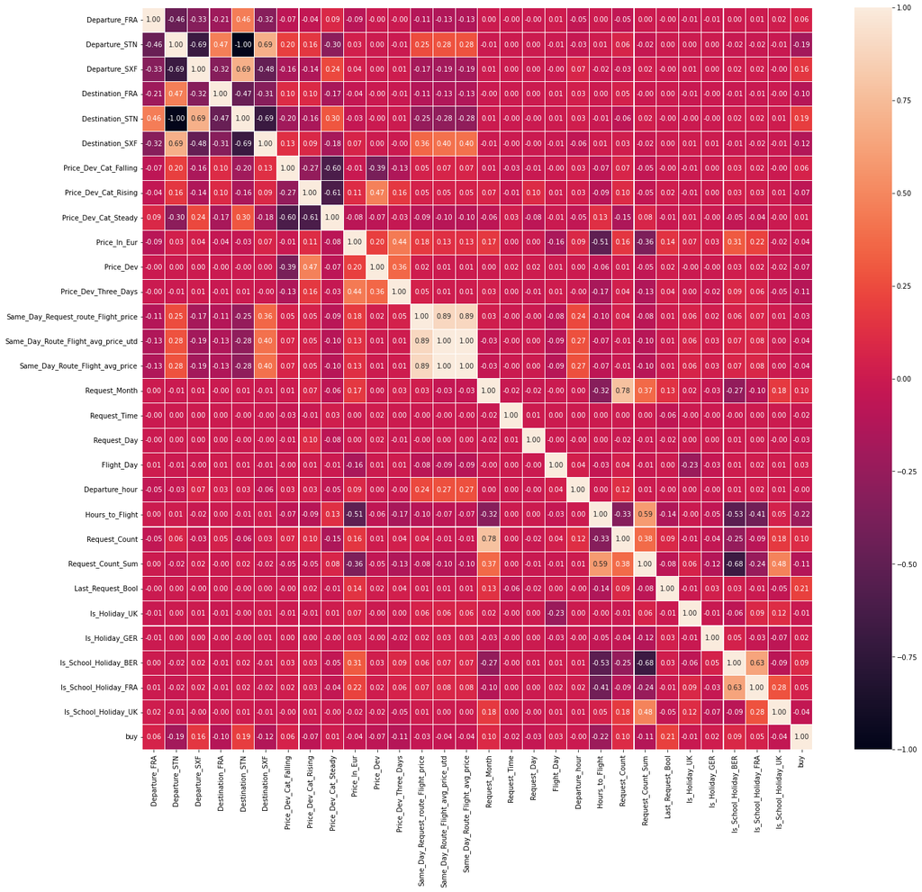

```python
customFeaturesDf = transformedDf[["Departure_FRA", "Departure_STN", "Departure_SXF", "Destination_FRA", "Destination_STN", "Destination_SXF", "Price_Dev_Cat_Falling",
                                  "Price_Dev_Cat_Rising", "Price_Dev_Cat_Steady", "Price_In_Eur",
                                  "Price_Dev", "Price_Dev_Three_Days", "Same_Day_Request_route_Flight_price",
                                  "Same_Day_Route_Flight_avg_price_utd", "Same_Day_Route_Flight_avg_price",
                                  "Request_Month", "Request_Time", "Request_Day", "Flight_Day", "Departure_hour",
                                  "Hours_to_Flight", "Request_Count", "Request_Count_Sum", "Last_Request_Bool", "Is_Holiday_UK", "Is_Holiday_GER",
                                  "Is_School_Holiday_BER", "Is_School_Holiday_FRA", "Is_School_Holiday_UK", "buy"]]
corr = customFeaturesDf.corr()
plt.figure(figsize=(22,20))
sns.heatmap(corr, annot=True,linewidths=0.1, fmt="0.2f")
plt.show
```

Korrelation zu der Zielvariable "buy"

```python
corr["buy"].sort_values(ascending=False)
```

```
buy                                    1.000000
Last_Request_Bool                      0.205586
Destination_STN                        0.192917
Departure_SXF                          0.160104
Request_Count                          0.102243
Request_Month                          0.095869
Is_School_Holiday_BER                  0.093627
Price_Dev_Cat_Falling                  0.058870
Departure_FRA                          0.055233
Is_School_Holiday_FRA                  0.052285
Flight_Day                             0.027445
Is_Holiday_GER                         0.020358
Price_Dev_Cat_Steady                   0.009395
Departure_hour                        -0.000522
Is_Holiday_UK                         -0.009399
Request_Time                          -0.020099
Same_Day_Request_route_Flight_price   -0.034259
Request_Day                           -0.034875
Same_Day_Route_Flight_avg_price       -0.036041
Same_Day_Route_Flight_avg_price_utd   -0.036041
Price_In_Eur                          -0.038199
Is_School_Holiday_UK                  -0.039851
Price_Dev                             -0.069817
Price_Dev_Cat_Rising                  -0.070002
Destination_FRA                       -0.103137
Price_Dev_Three_Days                  -0.106166
Request_Count_Sum                     -0.113745
Destination_SXF                       -0.123166
Departure_STN                         -0.192917
Hours_to_Flight                       -0.224813
Name: buy, dtype: float64
```

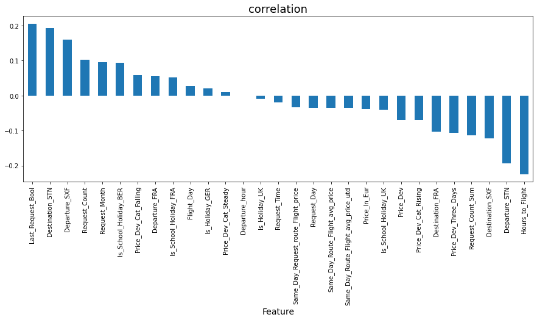

```python
plt.figure(figsize=(15,5))
corr["buy"].sort_values(ascending=False).drop(["buy"]).plot(kind="bar")
plt.xlabel("Feature",fontsize=14)
plt.title("correlation",fontsize=18)
plt.show()
```

# Zweiter Teil

Aufteilung der Algorithmen

- Bäume: Toan u. Flo
- Log. Regression: Frank
- SVM: Hung

```python
customFeaturesDf = transformedDf[["Departure_FRA", "Departure_STN", "Departure_SXF", "Destination_FRA", "Destination_STN", "Destination_SXF", "Price_Dev_Cat_Falling",
                                  "Price_Dev_Cat_Rising", "Price_Dev_Cat_Steady", "Price_In_Eur",
                                  "Price_Dev", "Price_Dev_Three_Days", "Same_Day_Request_route_Flight_price",
                                  "Request_Month", "Request_Time", "Request_Day", "Flight_Day", "Departure_hour",
                                  "Hours_to_Flight", "Request_Count", "Request_Count_Sum", "Last_Request_Bool", "Is_Holiday_UK", "Is_Holiday_GER",
                                  "Is_School_Holiday_BER", "Is_School_Holiday_FRA", "Is_School_Holiday_UK", "buy"]]
customFeaturesDf.info()
```

```
<class 'pandas.core.frame.DataFrame'>
RangeIndex: 83624 entries, 0 to 83623
Data columns (total 28 columns):
 #   Column                               Non-Null Count  Dtype
---  ------                               --------------  -----
 0   Departure_FRA                        83624 non-null  float64
 1   Departure_STN                        83624 non-null  float64
 2   Departure_SXF                        83624 non-null  float64
 3   Destination_FRA                      83624 non-null  float64
 4   Destination_STN                      83624 non-null  float64
 5   Destination_SXF                      83624 non-null  float64
 6   Price_Dev_Cat_Falling                83624 non-null  float64
 7   Price_Dev_Cat_Rising                 83624 non-null  float64
 8   Price_Dev_Cat_Steady                 83624 non-null  float64
 9   Price_In_Eur                         83624 non-null  float64
```

[output cut: 20 more lines]

```python
customFeaturesDf.describe()
```

|  | Departure_FRA | Departure_STN | Departure_SXF | Destination_FRA | Destination_STN | Destination_SXF | Price_Dev_Cat_Falling | Price_Dev_Cat_Rising | Price_Dev_Cat_Steady | Price_In_Eur | Price_Dev | Price_Dev_Three_Days | Same_Day_Request_route_Flight_price | Request_Month | Request_Time | Request_Day | Flight_Day | Departure_hour | Hours_to_Flight | Request_Count | Request_Count_Sum | Last_Request_Bool | Is_Holiday_UK | Is_Holiday_GER | Is_School_Holiday_BER | Is_School_Holiday_FRA | Is_School_Holiday_UK | buy |
| --- | --- | --- | --- | --- | --- | --- | --- | --- | --- | --- | --- | --- | --- | --- | --- | --- | --- | --- | --- | --- | --- | --- | --- | --- | --- | --- | --- | --- |
| count | 83624.000000 | 83624.000000 | 83624.000000 | 83624.000000 | 83624.000000 | 83624.000000 | 83624.000000 | 83624.000000 | 83624.000000 | 83624.000000 | 83624.000000 | 83624.000000 | 83624.000000 | 83624.000000 | 83624.000000 | 83624.000000 | 83624.000000 | 83624.000000 | 83624.000000 | 83624.000000 | 83624.000000 | 83624.000000 | 83624.000000 | 83624.000000 | 83624.000000 | 83624.000000 | 83624.000000 | 83624.000000 |
| mean | 0.178776 | 0.491270 | 0.329953 | 0.174507 | 0.508730 | 0.316763 | 0.208684 | 0.210944 | 0.580372 | 71.965080 | 0.974309 | 5.411629 | 6.637209 | 6.456125 | 16.975175 | 3.011193 | 2.933081 | 12.969889 | 929.921147 | 48.441153 | 103.337176 | 0.012042 | 0.044700 | 0.001303 | 0.355077 | 0.405398 | 0.777576 | 0.223835 |
| std | 0.383167 | 0.499927 | 0.470199 | 0.379547 | 0.499927 | 0.465217 | 0.406371 | 0.407981 | 0.493501 | 54.788483 | 16.086083 | 30.981142 | 26.935862 | 0.545032 | 5.999985 | 2.021693 | 1.999377 | 6.177936 | 548.569008 | 35.561468 | 29.246201 | 0.109074 | 0.206646 | 0.036080 | 0.478540 | 0.490972 | 0.415877 | 0.416815 |
| min | 0.000000 | 0.000000 | 0.000000 | 0.000000 | 0.000000 | 0.000000 | 0.000000 | 0.000000 | 0.000000 | 8.990000 | -226.440000 | -226.440000 | 0.000000 | 6.000000 | 11.000000 | 0.000000 | 0.000000 | 6.000000 | 19.000000 | 1.000000 | 4.000000 | 0.000000 | 0.000000 | 0.000000 | 0.000000 | 0.000000 | 0.000000 | 0.000000 |
| 25% | 0.000000 | 0.000000 | 0.000000 | 0.000000 | 0.000000 | 0.000000 | 0.000000 | 0.000000 | 0.000000 | 32.770000 | 0.000000 | -3.300000 | 0.000000 | 6.000000 | 11.000000 | 1.000000 | 1.000000 | 7.000000 | 475.000000 | 17.000000 | 89.000000 | 0.000000 | 0.000000 | 0.000000 | 0.000000 | 0.000000 | 1.000000 | 0.000000 |
| 50% | 0.000000 | 0.000000 | 0.000000 | 0.000000 | 1.000000 | 0.000000 | 0.000000 | 0.000000 | 1.000000 | 55.080000 | 0.000000 | 0.000000 | 0.000000 | 6.000000 | 11.000000 | 3.000000 | 3.000000 | 10.000000 | 883.000000 | 44.000000 | 121.000000 | 0.000000 | 0.000000 | 0.000000 | 0.000000 | 0.000000 | 1.000000 | 0.000000 |
| 75% | 0.000000 | 1.000000 | 1.000000 | 0.000000 | 1.000000 | 1.000000 | 0.000000 | 0.000000 | 1.000000 | 91.790000 | 0.000000 | 11.442500 | 0.000000 | 7.000000 | 23.000000 | 5.000000 | 5.000000 | 19.000000 | 1328.000000 | 77.000000 | 122.000000 | 0.000000 | 0.000000 | 0.000000 | 1.000000 | 1.000000 | 1.000000 | 0.000000 |
| max | 1.000000 | 1.000000 | 1.000000 | 1.000000 | 1.000000 | 1.000000 | 1.000000 | 1.000000 | 1.000000 | 372.960000 | 232.560000 | 266.190000 | 256.260000 | 8.000000 | 23.000000 | 6.000000 | 6.000000 | 22.000000 | 2375.000000 | 123.000000 | 123.000000 | 1.000000 | 1.000000 | 1.000000 | 1.000000 | 1.000000 | 1.000000 | 1.000000 |

## Data-Preprocessing for Testdata

```python
test_set
```

|  | Request_Date | Flight_Date | Departure_hour | flight_unique_id | route_abb | Price_In_Eur |
| --- | --- | --- | --- | --- | --- | --- |
| 0 | 2019-06-03T11:00:00Z | 2019-07-02 | 7 | 2019-07-02 FR 145 | STN-SXF | 30.32 |
| 1 | 2019-06-03T23:00:00Z | 2019-07-02 | 7 | 2019-07-02 FR 145 | STN-SXF | 44.53 |
| 2 | 2019-06-04T11:00:00Z | 2019-07-02 | 7 | 2019-07-02 FR 145 | STN-SXF | 44.47 |
| 3 | 2019-06-04T23:00:00Z | 2019-07-02 | 7 | 2019-07-02 FR 145 | STN-SXF | 44.47 |
| 4 | 2019-06-05T11:00:00Z | 2019-07-02 | 7 | 2019-07-02 FR 145 | STN-SXF | 44.52 |
| ... | ... | ... | ... | ... | ... | ... |
| 5578 | 2019-07-30T23:00:00Z | 2019-08-02 | 22 | 2019-08-02 FR 8545 | SXF-STN | 42.83 |
| 5579 | 2019-07-31T11:00:00Z | 2019-08-02 | 22 | 2019-08-02 FR 8545 | SXF-STN | 50.99 |
| 5580 | 2019-07-31T23:00:00Z | 2019-08-02 | 22 | 2019-08-02 FR 8545 | SXF-STN | 50.99 |
| 5581 | 2019-08-01T11:00:00Z | 2019-08-02 | 22 | 2019-08-02 FR 8545 | SXF-STN | 50.99 |
| 5582 | 2019-08-01T23:00:00Z | 2019-08-02 | 22 | 2019-08-02 FR 8545 | SXF-STN | 50.99 |

5583 rows × 6 columns

```python
# Price_Dev und Price_Dev_Three_Days
test_set['Request_Date'] = pd.to_datetime(test_set['Request_Date']).dt.tz_localize(None)
test_set.sort_values(["flight_unique_id", "Request_Date"])
for i in range(1, len(test_set)):
  flight_unique_id = test_set.loc[i, "flight_unique_id"]
  threeDaysBefore = test_set.loc[i, "Request_Date"] + datetime.timedelta(days = -3)

  if flight_unique_id == test_set.loc[i-1, "flight_unique_id"]:
    test_set.loc[i, "Price_Dev"] = test_set.loc[i, "Price_In_Eur"] - test_set.loc[i-1, "Price_In_Eur"]
  try:
    price = test_set.loc[(test_set["flight_unique_id"] == flight_unique_id) & (test_set["Request_Date"] == threeDaysBefore), "Price_In_Eur"].values
    priceDiff = price[0]
  except:
    priceDiff = 0
  if priceDiff != 0:
    test_set.loc[i, "Price_Dev_Three_Days"] = test_set.loc[i, "Price_In_Eur"] - priceDiff
test_set = test_set.fillna(0)
```

```python
# Request Count
test_set.sort_values(["flight_unique_id", "Request_Date"])
test_set.loc[0, "Request_Count"] = 1
for j in range(1, len(test_set)):
  if test_set.loc[j, "flight_unique_id"] != test_set.loc[j-1, "flight_unique_id"]:
    test_set.loc[j, "Request_Count"] = 1
  else:
    test_set.loc[j, "Request_Count"] = test_set.loc[j-1, "Request_Count"] + 1
```

```python
# Last Request
test_set["Last_Request"] = [test_set[test_set.flight_unique_id==flightid]["Request_Date"].max() for flightid in test_set["flight_unique_id"]]
test_set.loc[(test_set["Last_Request"] == test_set["Request_Date"]), "Last_Request_Bool"] = 1
test_set = test_set.fillna(0)
```

```python
# Sum of Request
test_set["Request_Count_Sum"] = [len(test_set[test_set.flight_unique_id == flightID]) for flightID in test_set["flight_unique_id"]]
```

```python
test_set.loc[test_set['Price_Dev'] > 0, 'Price_Dev_Cat'] = "Rising"
test_set.loc[test_set['Price_Dev'] < 0, 'Price_Dev_Cat'] = "Falling"
test_set.loc[test_set['Price_Dev'] == 0, 'Price_Dev_Cat'] = "Steady"
test_set['Flight_Date'] = pd.to_datetime(test_set['Flight_Date'], format="%Y-%m-%d").dt.tz_localize(None)
test_set["Flight_Date_Time"] = test_set["Flight_Date"] + pd.to_timedelta(test_set.Departure_hour, unit="h")
test_set['Request_Month'] = pd.DatetimeIndex(test_set['Request_Date']).month
test_set['Flight_Month'] = pd.DatetimeIndex(test_set['Flight_Date']).month
test_set['Request_Time'] = pd.DatetimeIndex(test_set['Request_Date']).hour
test_set['Request_Day'] = pd.DatetimeIndex(test_set['Request_Date']).day_name()
test_set['Flight_Day'] = pd.DatetimeIndex(test_set['Flight_Date']).day_name()
test_set['Hours_to_Flight'] = ((test_set['Flight_Date_Time'] - test_set['Request_Date']).dt.total_seconds() / 3600).astype(int)
test_set['Departure'] = test_set["route_abb"].apply(split_departure)
test_set['Destination'] = test_set["route_abb"].apply(split_destination)
```

```python
# Warning: this will take a lot of time

# return avg price and id of same flight
Same_Day_route_Flight_avg_price = [test_set[(test_set.flight_unique_id!=flightid) & (test_set.Flight_Date_Time==flightdate) & (test_set.route_abb==route)].groupby(["flight_unique_id"])["Price_In_Eur"].mean().reset_index() for flightid, flightdate, route in zip(test_set["flight_unique_id"], test_set["Flight_Date_Time"], test_set["route_abb"])]

# return price of same flight with same request date
Same_Day_Request_route_Flight_price = [test_set[(test_set.flight_unique_id!=flightid) & (test_set.Flight_Date_Time==flightdate) & (test_set.route_abb==route) & (test_set.Request_Date==requestdate)][["Price_In_Eur"]] for flightid, flightdate, route, requestdate in zip(test_set["flight_unique_id"], test_set["Flight_Date_Time"], test_set["route_abb"], test_set["Request_Date"])]

# return avg price and id of same flight up to i Request Date
Same_Day_route_Flight_avg_price_utd = [test_set[(test_set.flight_unique_id!=flightid) & (test_set.Flight_Date_Time==flightdate) & (test_set.route_abb==route) & (test_set.Request_Date<=requestdate)].groupby(["flight_unique_id"])["Price_In_Eur"].mean().reset_index() for flightid, flightdate, route, requestdate in zip(test_set["flight_unique_id"], test_set["Flight_Date_Time"], test_set["route_abb"], test_set["Request_Date"])]

# make features into dataframes and concat all together
df = concat_empty_dfs(Same_Day_route_Flight_avg_price, ["flight_unique_id", "Price_In_Eur"])
df = df.rename(columns={"Price_In_Eur":"Same_Day_Route_Flight_avg_price"})
df2 = concat_empty_dfs(Same_Day_route_Flight_avg_price_utd, ["flight_unique_id", "Price_In_Eur"])
df2 = df2.rename(columns={"Price_In_Eur":"Same_Day_Route_Flight_avg_price_utd"})
df3 = concat_empty_dfs(Same_Day_Request_route_Flight_price, ["Index", "Price_In_Eur"])
df3 = df3.rename(columns={"Price_In_Eur":"Same_Day_Request_route_Flight_price"})
df_same_day_flight_feature = pd.concat([df, df2["Same_Day_Route_Flight_avg_price_utd"], df3["Same_Day_Request_route_Flight_price"]], axis=1)
df_same_day_flight_feature = df_same_day_flight_feature.rename(columns={"flight_unique_id":"flight_unique_id_same_flight_date"})

#join with test_set
test_set = pd.concat([test_set, df_same_day_flight_feature], axis=1)
```

```python
uk_holidays = []
ger_holidays = []
for date in holidays.UnitedKingdom(years=2019).items():
  uk_holidays.append(str(date[0]))
for date in holidays.Germany(years=2019).items():
  ger_holidays.append(str(date[0]))
test_set['Is_Holiday_UK'] = [1 if str(val).split()[0] in uk_holidays else 0 for val in test_set['Flight_Date']]
test_set['Is_Holiday_GER'] = [1 if str(val).split()[0] in ger_holidays else 0 for val in test_set['Flight_Date']]

berlin_vacation1_start = datetime.datetime(year=2019, month=5, day = 31)
berlin_vacation1_end = datetime.datetime(year=2019, month=6, day = 11)
berlin_vacation2_start = datetime.datetime(year=2019, month=6, day=20)
berlin_vacation2_end = datetime.datetime(year=2019, month=8, day = 2)
frankfurt_vacation_start = datetime.datetime(year=2019, month = 7, day = 1)
frankfurt_vacation_end = datetime.datetime(year=2019, month=8, day=9)
uk_vacation_start = datetime.datetime(year=2019, month=7, day=6)
uk_vacation_end = datetime.datetime(year=2019, month=9, day=3)

berlin_school_holidays1 = pd.DataFrame()
berlin_school_holidays2 = pd.DataFrame()
berlin_school_holidays = pd.DataFrame()
frankfurt_school_holidays = pd.DataFrame()
uk_school_holidays = pd.DataFrame()

berlin_school_holidays1["Date"] = pd.date_range(berlin_vacation1_start, berlin_vacation1_end)
berlin_school_holidays2["Date"] = pd.date_range(berlin_vacation2_start, berlin_vacation2_end)
berlin_school_holidays = berlin_school_holidays1.append(berlin_school_holidays2, ignore_index = True)
frankfurt_school_holidays["Date"] = pd.date_range(frankfurt_vacation_start, frankfurt_vacation_end)
uk_school_holidays["Date"] = pd.date_range(uk_vacation_start, uk_vacation_end)

test_set['Is_School_Holiday_BER'] = test_set["Flight_Date"].isin(berlin_school_holidays["Date"]).astype(int)
test_set['Is_School_Holiday_FRA'] = test_set["Flight_Date"].isin(frankfurt_school_holidays["Date"]).astype(int)
test_set['Is_School_Holiday_UK'] = test_set["Flight_Date"].isin(uk_school_holidays["Date"]).astype(int)
```

```python
test_set.info()
```

```
<class 'pandas.core.frame.DataFrame'>
RangeIndex: 5583 entries, 0 to 5582
Data columns (total 31 columns):
 #   Column                               Non-Null Count  Dtype
---  ------                               --------------  -----
 0   Request_Date                         5583 non-null   datetime64[ns]
 1   Flight_Date                          5583 non-null   datetime64[ns]
 2   Departure_hour                       5583 non-null   int64
 3   flight_unique_id                     5583 non-null   object
 4   route_abb                            5583 non-null   object
 5   Price_In_Eur                         5583 non-null   float64
 6   Price_Dev                            5583 non-null   float64
 7   Price_Dev_Three_Days                 5583 non-null   float64
 8   Request_Count                        5583 non-null   float64
 9   Last_Request                         5583 non-null   datetime64[ns]
```

[output cut: 23 more lines]

```python
test_set_v2 = test_set[["Price_In_Eur", "Price_Dev", "Price_Dev_Three_Days", "Request_Day", "Request_Month",
                       "Request_Time", "Last_Request_Bool", "Flight_Day", "Departure_hour",
                       "Hours_to_Flight", "Departure", "Destination", "Price_Dev_Cat", "Request_Count", "Request_Count_Sum", "Is_Holiday_UK", "Is_Holiday_GER", "Is_School_Holiday_BER", "Is_School_Holiday_FRA", "Is_School_Holiday_UK",
                       "flight_unique_id_same_flight_date", "Same_Day_Route_Flight_avg_price", "Same_Day_Route_Flight_avg_price_utd", "Same_Day_Request_route_Flight_price"]]
test_set_v2.head()
```

|  | Price_In_Eur | Price_Dev | Price_Dev_Three_Days | Request_Day | Request_Month | Request_Time | Last_Request_Bool | Flight_Day | Departure_hour | Hours_to_Flight | ... | Request_Count_Sum | Is_Holiday_UK | Is_Holiday_GER | Is_School_Holiday_BER | Is_School_Holiday_FRA | Is_School_Holiday_UK | flight_unique_id_same_flight_date | Same_Day_Route_Flight_avg_price | Same_Day_Route_Flight_avg_price_utd | Same_Day_Request_route_Flight_price |
| --- | --- | --- | --- | --- | --- | --- | --- | --- | --- | --- | --- | --- | --- | --- | --- | --- | --- | --- | --- | --- | --- |
| 0 | 30.32 | 0.00 | 0.0 | Monday | 6 | 11 | 0.0 | Tuesday | 7 | 692 | ... | 54 | 0 | 0 | 1 | 1 | 0 | 0 | 0 | 0 | 0 |
| 1 | 44.53 | 14.21 | 0.0 | Monday | 6 | 23 | 0.0 | Tuesday | 7 | 680 | ... | 54 | 0 | 0 | 1 | 1 | 0 | 0 | 0 | 0 | 0 |
| 2 | 44.47 | -0.06 | 0.0 | Tuesday | 6 | 11 | 0.0 | Tuesday | 7 | 668 | ... | 54 | 0 | 0 | 1 | 1 | 0 | 0 | 0 | 0 | 0 |
| 3 | 44.47 | 0.00 | 0.0 | Tuesday | 6 | 23 | 0.0 | Tuesday | 7 | 656 | ... | 54 | 0 | 0 | 1 | 1 | 0 | 0 | 0 | 0 | 0 |
| 4 | 44.52 | 0.05 | 0.0 | Wednesday | 6 | 11 | 0.0 | Tuesday | 7 | 644 | ... | 54 | 0 | 0 | 1 | 1 | 0 | 0 | 0 | 0 | 0 |

5 rows × 24 columns

```python
#ohe
from sklearn import preprocessing
from sklearn.compose import make_column_transformer

ordinal_encoder = preprocessing.OrdinalEncoder()
ohe = preprocessing.OneHotEncoder()

categorical_cols = ["Departure_FRA", "Departure_STN", "Departure_SXF", "Destination_FRA", "Destination_STN", "Destination_SXF", "Price_Dev_Cat_Falling", "Price_Dev_Cat_Rising", "Price_Dev_Cat_Steady",
"Request_Day", "Flight_Day", "Price_In_Eur", "Price_Dev", "Price_Dev_Three_Days", "Request_Month", "Request_Time", "Last_Request_Bool",
 "Departure_hour", "Hours_to_Flight", "Request_Count", "Request_Count_Sum", "Is_Holiday_UK", "Is_Holiday_GER", "Is_School_Holiday_BER", "Is_School_Holiday_FRA", "Is_School_Holiday_UK", "flight_unique_id_same_flight_date",
 "Same_Day_Route_Flight_avg_price", "Same_Day_Route_Flight_avg_price_utd", "Same_Day_Request_route_Flight_price"]


column_trans = make_column_transformer(
    (ohe, ['Departure', 'Destination', 'Price_Dev_Cat']),
    (ordinal_encoder, ['Request_Day', 'Flight_Day']),
    remainder='passthrough'
)
transformed = column_trans.fit_transform(test_set_v2)

transformedDf = pd.DataFrame(transformed, columns=categorical_cols)
transformedDf.head()
```

|  | Departure_FRA | Departure_STN | Departure_SXF | Destination_FRA | Destination_STN | Destination_SXF | Price_Dev_Cat_Falling | Price_Dev_Cat_Rising | Price_Dev_Cat_Steady | Request_Day | ... | Request_Count_Sum | Is_Holiday_UK | Is_Holiday_GER | Is_School_Holiday_BER | Is_School_Holiday_FRA | Is_School_Holiday_UK | flight_unique_id_same_flight_date | Same_Day_Route_Flight_avg_price | Same_Day_Route_Flight_avg_price_utd | Same_Day_Request_route_Flight_price |
| --- | --- | --- | --- | --- | --- | --- | --- | --- | --- | --- | --- | --- | --- | --- | --- | --- | --- | --- | --- | --- | --- |
| 0 | 0.0 | 1.0 | 0.0 | 0.0 | 0.0 | 1.0 | 0.0 | 0.0 | 1.0 | 1.0 | ... | 54.0 | 0.0 | 0.0 | 1.0 | 1.0 | 0.0 | 0.0 | 0.0 | 0.0 | 0.0 |
| 1 | 0.0 | 1.0 | 0.0 | 0.0 | 0.0 | 1.0 | 0.0 | 1.0 | 0.0 | 1.0 | ... | 54.0 | 0.0 | 0.0 | 1.0 | 1.0 | 0.0 | 0.0 | 0.0 | 0.0 | 0.0 |
| 2 | 0.0 | 1.0 | 0.0 | 0.0 | 0.0 | 1.0 | 1.0 | 0.0 | 0.0 | 5.0 | ... | 54.0 | 0.0 | 0.0 | 1.0 | 1.0 | 0.0 | 0.0 | 0.0 | 0.0 | 0.0 |
| 3 | 0.0 | 1.0 | 0.0 | 0.0 | 0.0 | 1.0 | 0.0 | 0.0 | 1.0 | 5.0 | ... | 54.0 | 0.0 | 0.0 | 1.0 | 1.0 | 0.0 | 0.0 | 0.0 | 0.0 | 0.0 |
| 4 | 0.0 | 1.0 | 0.0 | 0.0 | 0.0 | 1.0 | 0.0 | 1.0 | 0.0 | 6.0 | ... | 54.0 | 0.0 | 0.0 | 1.0 | 1.0 | 0.0 | 0.0 | 0.0 | 0.0 | 0.0 |

5 rows × 30 columns

```python
transformedDf = transformedDf[["Departure_FRA", "Departure_STN", "Departure_SXF", "Destination_FRA", "Destination_STN", "Destination_SXF", "Price_Dev_Cat_Falling",
                                  "Price_Dev_Cat_Rising", "Price_Dev_Cat_Steady", "Price_In_Eur",
                                  "Price_Dev", "Price_Dev_Three_Days", "Same_Day_Request_route_Flight_price",
                                  "Request_Month", "Request_Time", "Request_Day", "Flight_Day", "Departure_hour",
                                  "Hours_to_Flight", "Request_Count", "Request_Count_Sum", "Last_Request_Bool", "Is_Holiday_UK", "Is_Holiday_GER",
                                  "Is_School_Holiday_BER", "Is_School_Holiday_FRA", "Is_School_Holiday_UK"]]
transformedDf.info()
```

```
<class 'pandas.core.frame.DataFrame'>
RangeIndex: 5583 entries, 0 to 5582
Data columns (total 27 columns):
 #   Column                               Non-Null Count  Dtype
---  ------                               --------------  -----
 0   Departure_FRA                        5583 non-null   float64
 1   Departure_STN                        5583 non-null   float64
 2   Departure_SXF                        5583 non-null   float64
 3   Destination_FRA                      5583 non-null   float64
 4   Destination_STN                      5583 non-null   float64
 5   Destination_SXF                      5583 non-null   float64
 6   Price_Dev_Cat_Falling                5583 non-null   float64
 7   Price_Dev_Cat_Rising                 5583 non-null   float64
 8   Price_Dev_Cat_Steady                 5583 non-null   float64
 9   Price_In_Eur                         5583 non-null   float64
```

[output cut: 19 more lines]

```python
transformedDf.to_csv("/content/drive/MyDrive/Data Mining Gruppe A/test_set_ohe.csv", index=False)
```